# Wind speed

## WIND-OBSERVATION speed rate

The rate of horizontal travel of air past a fixed point.

MIN: 0000 MAX: 0900 UNITS: meters per second

SCALING FACTOR: 10

DOM: A general domain comprised of the numeric characters (0-9).

9999 = Missing.

Atribút wind speed reprezentuje rýchlosť vetra v metroch za sekundu.

```r
all_data <- read.csv(file= "../data/all.csv")
```

```r
summary(all_data$WND_SPEED)
```

```
##    Min. 1st Qu.  Median    Mean 3rd Qu.    Max.    NA's
##   0.000   0.000   1.000   1.716   2.600  26.000   18057
```

```r
all_data['WND_SPEED'] %>% profiling_num()
```

| variable | mean | std_dev | variation_coef | p_01 | p_05 | p_25 | p_50 | p_75 | p_95 | p_99 | skewness | kurtosis | iqr | range_98 | range_80 |
| --- | --- | --- | --- | --- | --- | --- | --- | --- | --- | --- | --- | --- | --- | --- | --- |
| WND_SPEED | 1.715614 | 1.84761 | 1.076938 | 0 | 0 | 0 | 1 | 2.6 | 5.1 | 8 | 1.576615 | 6.190994 | 2.6 | [0, 8] | [0, 4.1] |

```r
getmode(na.omit(all_data$WND_SPEED)) # modus
```

```
## [1] 0
```

### Centralna poloha dat

Hodnota výberového mediánu je 1 a hodnota výberového priemeru 1.716. Keďže stredná hodnota (medián) je nižšia ako priemer, hodnotu priemeru mohli ovplyvniť výrazne vyššie hodnoty, prípadne extrémne vysoké hodnoty. Takže stredná hodnota rýchlosti vetra je 1 m/s.

Modus - najčastejšia hodnota je 0 m/s.

```r
var(all_data$WND_SPEED, na.rm = T) # rozptyl
```

```
## [1] 3.413663
```

```r
max(all_data$WND_SPEED, na.rm = T) - min(all_data$WND_SPEED, na.rm = T) # variacne rozpatie
```

```
## [1] 26
```

```r
# Interquartile range and outliers
Q1 <- quantile(all_data$WND_SPEED, 0.25, na.rm = T) # 25% hodnot je mensich a 75% vacsich
Q3 <- quantile(all_data$WND_SPEED, 0.75, na.rm = T) # 75% hodnot je mensich a 25% vacsich
IQR <- IQR(all_data$WND_SPEED, na.rm = T) # interquartile range
IQR_dev <- IQR/2

# odlahle hodnoty
length(which(all_data$WND_SPEED < (Q1 - 1.5*IQR)))
```

```
## [1] 0
```

```r
length(which(all_data$WND_SPEED > (Q3 + 1.5*IQR)))
```

```
## [1] 10253
```

```r
# extremne hodnoty
length(which(all_data$WND_SPEED < (Q1 - 3*IQR)))
```

```
## [1] 0
```

```r
length(which(all_data$WND_SPEED > (Q3 + 3*IQR)))
```

```
## [1] 561
```

### Variabilita

Výberový rozptyl je 3.413663.

Výberová smerodajná odchýlka je 1.8476. To znamená, že rýchlosť vetra sa pohybuje približne v rozsahu 1.8476 m/s okolo priemeru.

Medzikvartilová odchýlka (IQR/2) je 1.3, teda hodnoty sú rozptýlené približne 1.3 okolo mediánu.

Variačné rozpätie je 26. Daná hodnota predstavuje rozdiel medzi maximálnou a minimálnou nameranou hodnotou rýchlosti vetra. Maximálna rýchlosť vetra je 26 m/s a minimálna 0 m/s.

Variačný koeficient rýchlosti vetra je 1.076938, čo je 108%. V porovanní s ostatnými atribútmi má rýchlosť vetra vyššiu variabilitu, podobnú ako teplota.

### Asymetria

Hodnota šikmosti je kladná 1.58, to znamená, že väčšina hodnôt sa nachádza pod priemerom. Dáta sú zošimené a nejde o symetrické rozdelenie okolo strednej hodnoty.

Hodnota špicatosti je 6.2, je väčšia ako 3 teda hodnoty majú veľmi špicaté rozdelenie. To znamená, že početnosti hodnôt v súbore sú prevažne sústredené okolo strednej hodnoty.

### Boxplot

Hodnota 3.kvartilu je 2.6 a hodnota 1. kvartilu 0, teda medzikvartilové rozpätie (IQR) je 2.6. Uprostred krabice je zvýraznený medián hrubou čiernou čiarou (1). Vidíme, že krabica boxplotu sa nachádza v nižších hodnotách, teda 50% hodnôt tvoria nízke hodnoty, avšak je tu aj niekoľko vysokých hodnôt.

Ďalej z boxplotu vidieť maximálnu a minimálnu hodnotu (vonkajšie hradby boxplotu). Maximálna hodnota (6.5) je vypočítaná ako 3.kvartil + 1.5 * IQR (medzikvartilové rozpätie). Minimálna hodnota je vypočítaná ako 1.kvartil - 1.5 * IQR (medzikvartilové rozpätie), v prípade rýchlosti je minimálna hodnota 0.

Všetky hodnoty nachádzajúce sa nad a pod maximálnou a minimálnou hodnotou môžme považovať za odľahlé hodnoty. Počet odľahlých hodnôt nad maximálnou hodnotou je 10253, pod minimálnou sa nenachádzajú žiadne odľahlé hodnoty.

Nakoniec pre odľahlé hodnoty overíme či patria medzi extrémne. Horná hranica extrémych hodnôt je vypočítaná ako 3.kvartil + 3 * IQR. Dolná hranica extrémych hodnôt je vypočítaná ako 1.kvartil - 3 * IQR. V dátach sa nachádza 561 extrémne vysokých hodnôt, ktoré sú vyššie ako hodnota 3.kvartilu + 3 * IQR, teda vyššie ako 10.4 m/s.

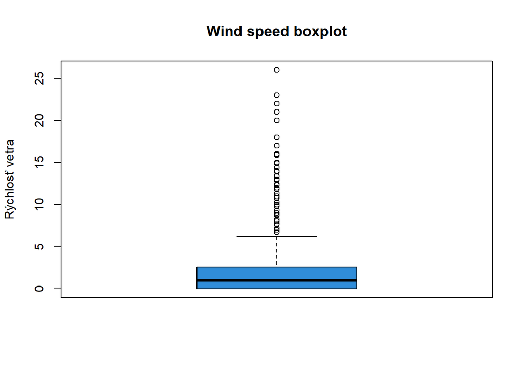

```r
# boxplot
boxplot(all_data$WND_SPEED, col = "#308dd9", ylab = "Rýchlosť vetra", main = "Wind speed boxplot")
```

### Histogram

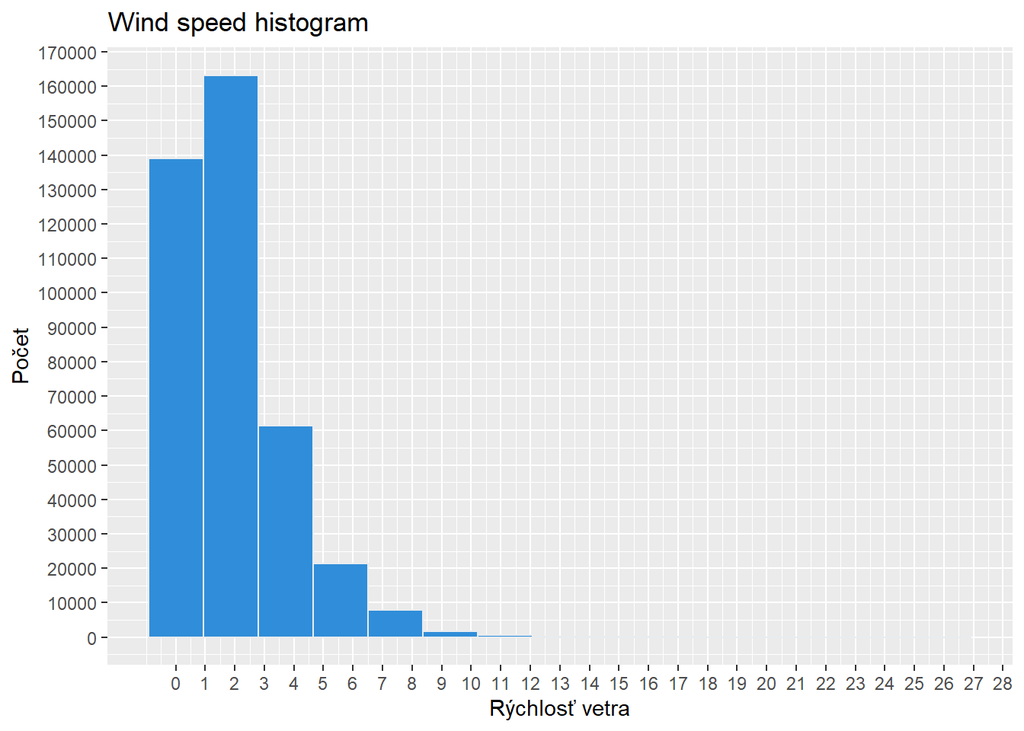

```r
# histogram
ggplot(all_data, aes(x = WND_SPEED)) +
  geom_histogram(bins = 15, fill = "#308dd9", color = "#e9ecef") +
  labs(title = paste("Wind speed histogram")) +
  xlab("Rýchlosť vetra") +
  ylab("Počet") +
  scale_x_continuous(breaks = seq(0, 30, by = 1)) +
  scale_y_continuous(breaks = seq(0, 200000, by = 10000))
```

### Graf hustoty

Graf hustoty slúži na porovnanie priebehu hustoty pravdepodobnosti normálneho rozdelenia (zelená čiara) a odhadu hustoty vypočítaného z namernaých hodnôt rýchlosti vetra (červená čiara). Čiary sa výrazne líšia, teda nejde o normálne rozdelenie. Modrá prerušovaná čiara predstavuje priemernú rýchlosť vetra. V dátach sa nachádza niekoľko vrcholov, najvyšší je v bode 0.

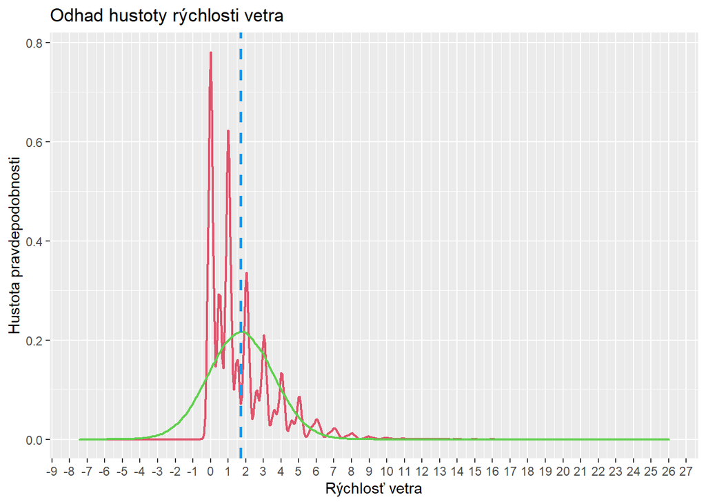

```r
# denisty plot
# data z normalneho rozdelenia
data_norm <- data.frame(dens = c(rnorm(length(na.omit(all_data$WND_SPEED)), mean(all_data$WND_SPEED, na.rm = T), sd(all_data$WND_SPEED, na.rm = T))))

# porovnanie hodnot normalneho rozdelenia a WND_SPEED
ggplot(all_data, aes(x = WND_SPEED), color = 3) +
  geom_density(color = 2, size = 0.8) +
  geom_density(data_norm, mapping = aes(x = dens), color = 3, size = 0.8) +
  geom_vline(aes(xintercept = mean(WND_SPEED, na.rm = T)),
            color = 4, linetype = "dashed", size = 1) +
  scale_x_continuous(breaks = seq(-20, 50, by = 1)) +
  labs(title = paste("Odhad hustoty rýchlosti vetra")) +
  xlab("Rýchlosť vetra") +
  ylab("Hustota pravdepodobnosti")
```

### Husľový graf

Husľový graf doplnený o hlavné kvartily zobrazuje rozdelenie hustoty, pričom aj podľa tohto grafu vidíme, že nejde o normálne rozdelenie. Dáta sú striedavo rozdelené, najviac v intervale od 0 po 8 ale vyskytujú sa v nich aj vysoké hodnoty (dlhá čiara).

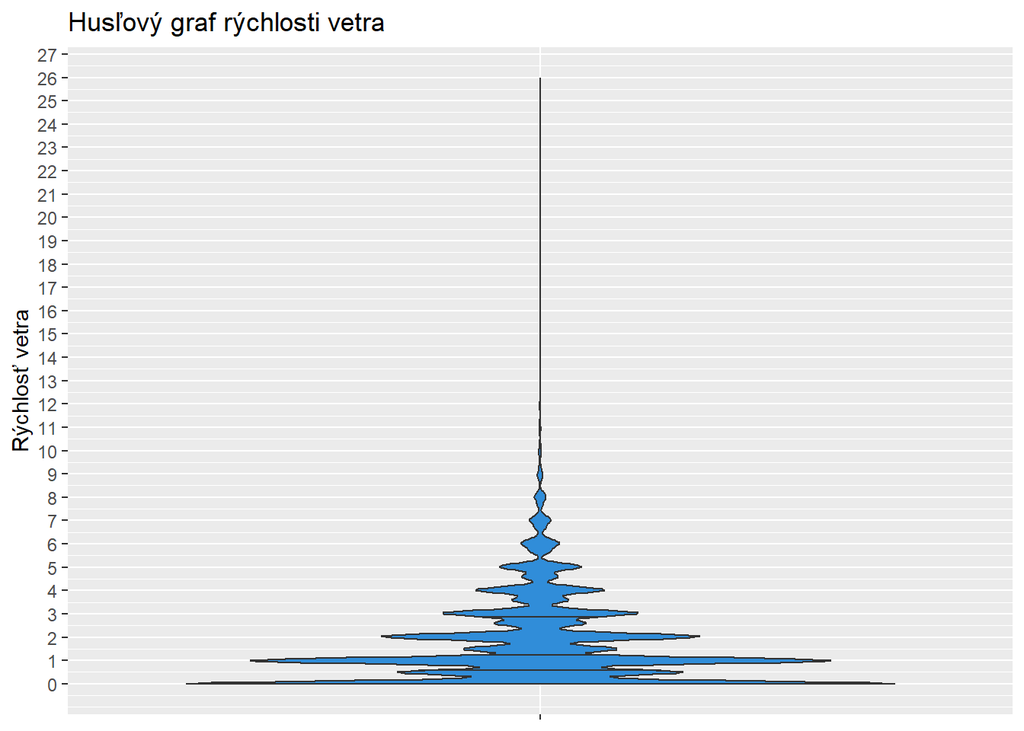

```r
# violin plot
df <- all_data %>%
  dplyr::select('WND_SPEED') %>%
  tidyr::gather(key = 'label', value = 'speed')

ggplot(data = df, aes(factor(label), speed, fill = speed)) +
  geom_violin(draw_quantiles = c(0.25, 0.5, 0.75), fill = "#308dd9") +
  labs(title = paste("Husľový graf rýchlosti vetra"), y = "Rýchlosť vetra", fill = "speed") +
  theme(axis.title.x = element_blank()) +
  theme(axis.text.x = element_blank()) +
  scale_y_continuous(breaks = seq(0, 30, by = 1))
```

### Q-Q graf

Graf zobrazuje odchýlku empirického od teoretického normálneho rozdelenia. Empirické rozdelenie je v našom prípade rozdelenie nameraných hodnôt rýchosti vetra. Keďže body sa výrazne odchyľujú od priamky normálneho rozdelenia, môžeme povedať, že rozdelenie hodnôt rýchlosti vetra nie je normálne.

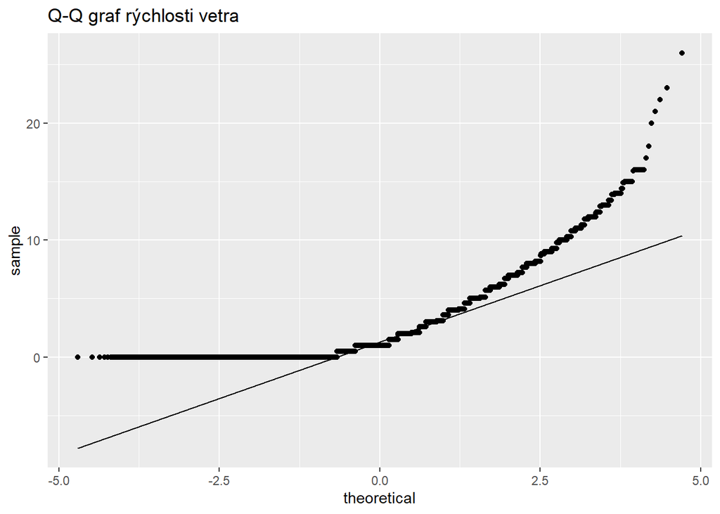

```r
# QQ plot
ggplot(data = all_data, aes(sample = WND_SPEED)) +
  stat_qq() +
  stat_qq_line() +
  labs(title = paste("Q-Q graf rýchlosti vetra"))
```

### Graf polosum

Z grafu vidíme, že hodnoty nie sú symetrické.

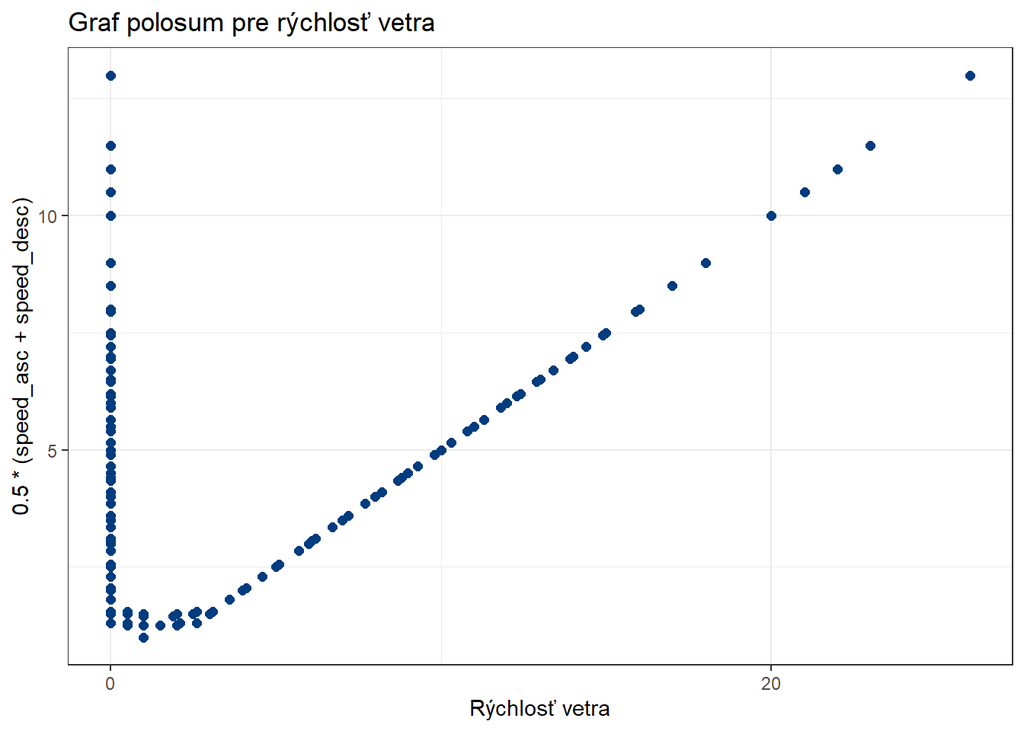

```r
# polosum
speed <- all_data$WND_SPEED
speed_asc <- sort(speed, decreasing = FALSE)
speed_desc <- sort(speed, decreasing = TRUE)

ggplot(data.frame(speed_asc), aes(x = speed_asc, y = 0.5*(speed_asc + speed_desc))) +
  geom_point(size = 2, color = "#013c7f") +
  scale_x_continuous(breaks = seq(0, 400, by = 20)) +
  labs(title = "Graf polosum pre rýchlosť vetra", x = "Rýchlosť vetra") +
  theme_bw()
```